# individual2.Rmd

Samuel Cole

4/18/2019

**Part one: Accident data** Are there some days of the week where more accidents happen than on others (use variable DAY_WEEK)?

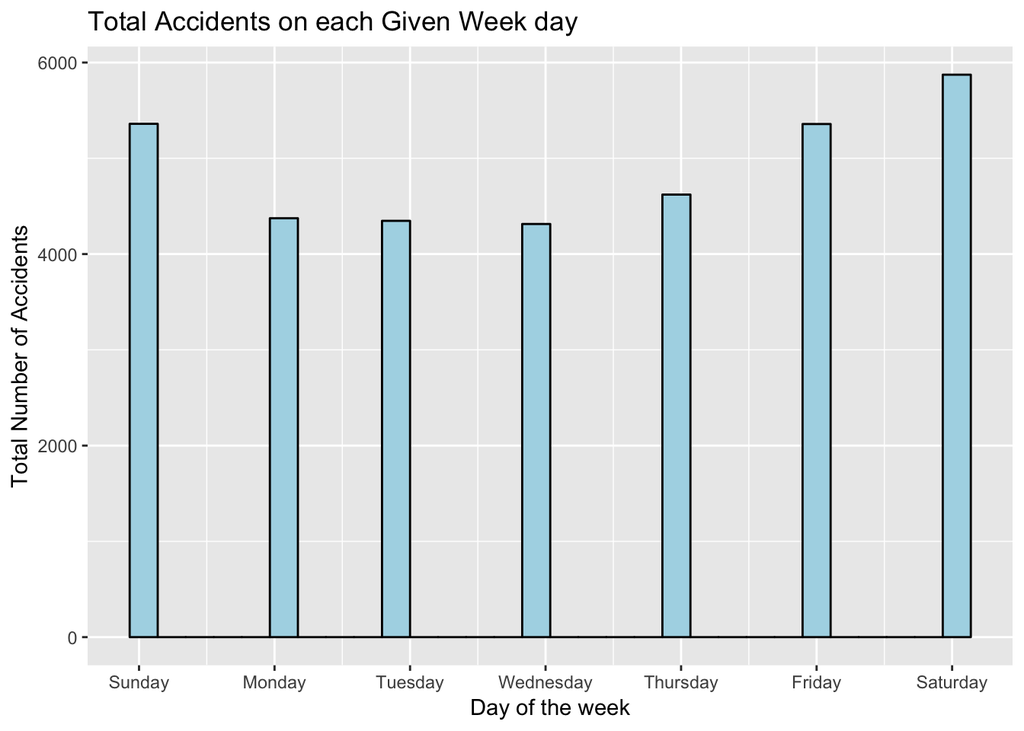

```r
library(ggplot2)
ggplot(data = acc, aes(x=DAY_WEEK)) + geom_histogram(color="black", fill="light blue") + ylab("Total Number of Accidents") + xlab("Day of the week") + ggtitle("Total Accidents on each Given Week day") + scale_x_continuous(breaks= c(1, 2, 3, 4, 5, 6, 7), labels = c("Sunday", "Monday", "Tuesday","Wednesday", "Thursday", "Friday", "Saturday"))
```

There are more accidents on Friday, Saturday, and Sunday. These are all considered the weekend, so the weekend works as well. What time of the day do accidents happen (use variable HOUR)?

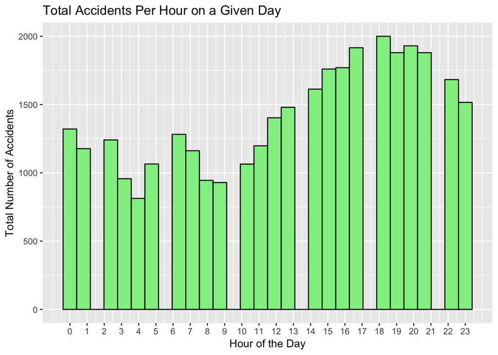

```r
acc$HOUR[acc$HOUR == 99] <- NA
#We have to change 99 to null in order to graph this as a per hour accident graph. 99 is the NULL hour, because the 0 hour is from midnight to 1.
ggplot(data = acc, aes(x=HOUR)) + geom_histogram(color="Black", fill="light green") + ylab("Total Number of Accidents") + xlab("Hour of the Day") + ggtitle("Total Accidents Per Hour on a Given Day") + scale_x_continuous(breaks= c(0, 1, 2, 3, 4, 5, 6, 7, 8, 9, 10, 11, 12, 13, 14, 15, 16, 17, 18, 19, 20, 21, 22, 23))
```

What is the number of accidents with at least one drunk driver (use variable DRUNK_DR)?

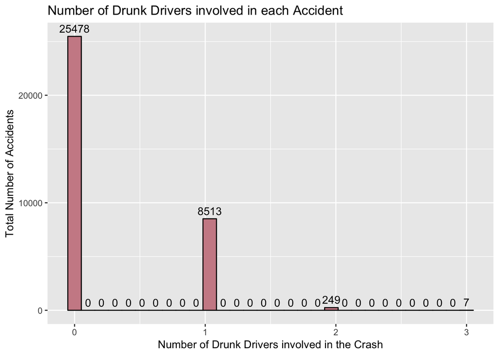

```r
ggplot(data = acc, aes(x=DRUNK_DR)) + geom_histogram(color="black", fill="lightpink3") + ylab("Total Number of Accidents") + xlab("Number of Drunk Drivers involved in the Crash") + ggtitle("Number of Drunk Drivers involved in each Accident") + scale_x_continuous(breaks= c(0, 1, 2, 3)) + stat_bin(aes(y=..count.., label=..count..), geom="text", vjust=-.5)
```

```r
library(tidyverse)
drunkDriving <- acc %>% filter(DRUNK_DR > 0)
count(drunkDriving)
```

```
## # A tibble: 1 x 1
##       n
##   <int>
## 1  8769
```

As we can see, there is 8769 cases where a drunk Driver was involved in the crash. The graph shows the overall layout of the number of Drunk Drivers per crash.

**Part two: Connecting data**

Load the person table. Identify drivers (PER_TYP == 1, see fars manual) and subset on them.

```r
per <- read.csv("https://raw.githubusercontent.com/xdaiISU/ds202materials/master/hwlabs/fars2017/person.csv", stringsAsFactors = FALSE)
names(acc)
```

```
##  [1] "STATE"      "ST_CASE"    "VE_TOTAL"   "VE_FORMS"   "PVH_INVL"
##  [6] "PEDS"       "PERNOTMVIT" "PERMVIT"    "PERSONS"    "COUNTY"
## [11] "CITY"       "DAY"        "MONTH"      "YEAR"       "DAY_WEEK"
## [16] "HOUR"       "MINUTE"     "NHS"        "RUR_URB"    "FUNC_SYS"
## [21] "RD_OWNER"   "ROUTE"      "TWAY_ID"    "TWAY_ID2"   "MILEPT"
## [26] "LATITUDE"   "LONGITUD"   "SP_JUR"     "HARM_EV"    "MAN_COLL"
## [31] "RELJCT1"    "RELJCT2"    "TYP_INT"    "WRK_ZONE"   "REL_ROAD"
## [36] "LGT_COND"   "WEATHER1"   "WEATHER2"   "WEATHER"    "SCH_BUS"
## [41] "RAIL"       "NOT_HOUR"   "NOT_MIN"    "ARR_HOUR"   "ARR_MIN"
## [46] "HOSP_HR"    "HOSP_MN"    "CF1"        "CF2"        "CF3"
## [51] "FATALS"     "DRUNK_DR"
```

```r
drivers = per %>% filter(PER_TYP == 1)
```

Join accident and driver table (work out which variable(s) to use)

```r
acc.drivers <- inner_join(acc, drivers, by= "ST_CASE")
```

```r
acc.driver.clean <- acc.drivers %>% group_by(DAY_WEEK, HOUR.x, SEX)
tally(acc.driver.clean)
```

```
## # A tibble: 579 x 4
## # Groups:   DAY_WEEK, HOUR.x [?]
##    DAY_WEEK HOUR.x   SEX     n
##       <int>  <int> <int> <int>
##  1        1      0     1   305
##  2        1      0     2    74
##  3        1      0     8     1
##  4        1      0     9    20
##  5        1      1     1   300
##  6        1      1     2    77
##  7        1      1     9    14
##  8        1      2     1   338
##  9        1      2     2   101
## 10        1      2     8     4
## # … with 569 more rows
```

**Part three: Connecting data and make maps**

Now plot a choropleth map of accidents on a county level

```r
library(classdata)
library(tidyverse)
library("readxl")
library(dplyr)
CountyData <- read_excel("County Codes United States.xlsx")
```

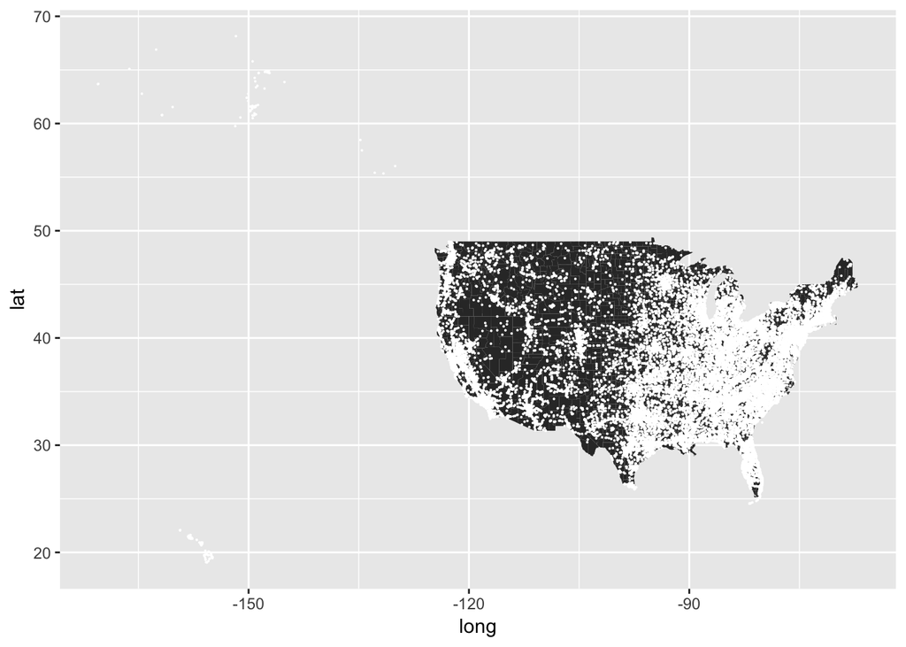

```r
county <- map_data("county")
#ggplot(county, aes(x=long, y = lat)) + geom_polygon(aes(group=group))
#acc.driver.clean$`County Code` <- acc.driver.clean$COUNTY.x
#CountyData$`County Code` <- as.numeric(CountyData$`County Code`)
#str(CountyData)
#acc.driver.clean <- acc.driver.clean %>% select(`County Code`, LONGITUD, LATITUDE, DAY_WEEK, HOUR.x, SEX)
#CountyData <- CountyData %>% select(`County Code`, `County Name`)
#firstJoin <- inner_join(acc.driver.clean, CountyData, by = "County Code")

ggplot(county, aes(x=long, y=lat)) +geom_polygon(aes(group=group)) + geom_point(aes(x=LONGITUD, y=LATITUDE), data=acc %>% filter(LONGITUD < 0, LATITUDE > -130), size=0.001, color='white')
```

Read the description for the STATE and COUNTY columns in the FARS manual. The state & county codes are Geographic Locator Codes (GLCs) from the General Services Administration’s (GSA) publication Use readxl::read_xlsx to read in the GLCs

```r
GLC <- read_xlsx("FRPP GLC United States.xlsx")
```

```
## * … and 4 more
```

```r
glc.us<-readxl::read_xlsx("FRPP GLC United States.xlsx")
```

```
## * … and 4 more
```

```r
glc.terr<-readxl::read_xlsx("FRPP GLC US Territories.xlsx")
```

```
## * … and 4 more
```

```r
colnames(glc.us)<-glc.us[1,]
glc.us<-glc.us[-1,]
colnames(glc.terr)<-glc.terr[1,]
glc.terr<-glc.terr[-1,]

acc <- mutate(acc, `County Code` = COUNTY)
acc$COUNTY <- as.numeric(acc$COUNTY)
acc$`County Code` <- as.numeric(acc$`County Code`)
joined.glc<- inner_join(glc.us, glc.terr, by = "County Code")
joined.glc$`County Code` <- as.numeric(joined.glc$`County Code`)
three_join <- inner_join(joined.glc, acc, by = "County Code")
filtered_three_join <- select(three_join, `County Code`, LATITUDE, LONGITUD, COUNTY, DAY, MONTH, YEAR, HOUR, ST_CASE)
filtered_three_join
```

```
## # A tibble: 4,988,715 x 9
##    `County Code` LATITUDE LONGITUD COUNTY   DAY MONTH  YEAR  HOUR ST_CASE
##            <dbl>    <dbl>    <dbl>  <dbl> <int> <int> <int> <int>   <int>
##  1           123     32.9    -85.8    123    11     1  2017     0   10025
##  2           123     32.6    -85.8    123    17     5  2017     6   10293
##  3           123     32.6    -85.8    123    26    10  2017    18   10674
##  4           123     32.9    -85.9    123     8     1  2017    16   10835
##  5           123     32.9    -86.0    123    16     2  2017    14   10836
##  6           123     35.1    -90.6    123     6     1  2017     8   50014
##  7           123     35.1    -90.6    123    13     4  2017     7   50104
##  8           123     35.1    -90.8    123    18     4  2017    19   50116
##  9           123     35.0    -90.7    123    14     7  2017     1   50256
## 10           123     35.0    -90.9    123    15    10  2017     8   50364
## # … with 4,988,705 more rows
```

```r
#ggplot(county, aes(x=long, y=lat))+geom_polygon(aes(group=group))+geom_point(aes(x=LONGITUD, y=LATITUDE), data=three_join, size=0.0001, color="white")
```

```r
#ggplot(county, aes(x=long, y=lat))+geom_polygon(aes(group=group))+geom_point(aes(x=LONGITUD, y=LATITUDE), data=three_join  %>% filter(LONGITUD <0 & LONGITUD > -130), size=0.0001, color="white")+facet_wrap(~MONTH)
```